# Introduction to renewal processes II

## More advanced renewal theorems

We will discuss some more advanced renewal theorems that will be useful for applications later.

- We call the function \(m(t):= \mathbb{E} N(t)\) the **renewal function**.

**Theorem (Elementary renewal theorem):** The renewal function satisfies \(m(t)/ t \to (\mu)^{-1}\), where \(\mu\) is the mean inter-arrival time.

- We already know that if \(N\) is the renewal process, then \(N(t)/t \to (\mu)^{-1}\)–we need to justify the interchange of limits: \[ \lim_{t \to \infty} \frac{ \mathbb{E} N(t)}{t} = \mathbb{E} \Big( \lim_{t \to \infty} \frac{ N(t)}{t} \Big).\]

## Lattice-type random variables

We say that the law of a real-valued random variable is of **lattice-type** if for some \(a >0\) the random variables takes values in the set \[a\mathbb{Z} = \{az: z \in \mathbb{Z}\}\] with probability one; the largest such possible \(a\) is called the **span** of the lattice. Note that continuous random variables are of non-lattice type.

## Blackwell’s renewal theorem

A renewal process with inter-arrival times that are of non-lattice type has a renewal function \(m\) that satisfies \[\frac{m(t+h) - m(t)}{h} \to \frac{1}{\mu},\] as \(t \to \infty\), for all \(h >0\). Furthermore, in the case of a lattice-type inter-arrival time with span \(a\), the limit holds if we choose \(h\) to be integer multiples of \(a\).

## Riemann-Stieltjes integration

Recall that it is possible to define Stieltjes’ extension of the Riemann integral where we have \[ \int_a ^b f(x) d\phi(x) = \int_a^b f(x) \phi'(x) dx\] if \(\phi\) is continuously differentiable; the key is that we can make sense of the left-hand side even if \(\phi\) is just monotone and right continuous.

## continued

Going back to the definition of Riemann sums, we replace expressions of the sort: \[ f(x_i^{*})(x_{i+1} - x_i)\] with \[ f(x_i^{*})(\phi(x_{i+1}) - \phi(x_i)).\] Thus the length of an interval \((x_i, x_{i+1}]\) is weighted by the function \(\phi\).

## Notes

- Much of the theory is similar, but it also allows us to have a more unified treatment of sums and integrals.
- We need to be a bit careful about endpoints in the integration as jumps are possible.
- We will take the convention that an integrals are taken over intervals of the form. \((a, b]\).
- Working from the definitions it is possible to show that if \(\phi\) is step function with jumps at points \(a < s_1< \cdots <s_n < b\), then \[\int_a ^b f(x) d\phi(x) = \sum_{i=1} ^n f(s_j)[\phi(s_j+)- \phi(s_j-)].\]

## continued

- This extension of the integral is useful for probability and statistics, since the cumulative distribution function \(F\) of a random variable \(X\), is monotone and right-continuous, we have can take:

\[ \mathbb{E}(X) = \int xdF(x),\] where this formula gives the correct expressions whether \(X\) is a continuous random variable or a discrete random variable or of *mixed type*.

- In what follows, it may be easier to pretend that the renewal function \(m\) is differentiable and continuous so that \[ dm(x) = m'(x) dx.\]

## Key renewal theorem

- Let \(g:[0, \infty) \to [0, \infty)\) be non-increasing with \(\int_0 ^{\infty} g(x)dx < \infty\).
- A renewal process with inter-arrival times that are of non-lattice type has a renewal function \(m\) that satisfies \[\int_0 ^t g(t-x) dm(x) \to \frac{1}{\mu} \int_0 ^{\infty} g(x)dx\] as \(t \to \infty\).

## notes

Notice that if we choose \(g(t) = \mathbf{1}_{[0, h]}(t)\), we have that \[\int_0 ^{t+h} g(t+h-x) dm(x) = \int_{t} ^ {t+h} dm(x) = m(t+h)-m(t)\] and \[ \frac{1}{\mu} \int_0 ^{\infty} g(x)dx = \frac{1}{\mu} \int_0 ^{\infty} g(x)dx = \frac{1}{\mu} \int_0 ^h dx = \frac{h}{\mu}.\]

## Basic renewal equation

If \(m\) is a renewal function, then it satisfies \[ m(t) = F(t) + \int_0^t m(t-x)dF(x),\] where \(F\) is the cumulative distribution function of the inter-arrival times.

## Proof

- Let \(X_1, X_2, \ldots\) be the inter-arrival times. We condition on the time of first arrival \(X_1\). Observe that if we set

\[\phi(x) = \mathbb{E}(N(t) | X_1 = x )\]

- we have \(\phi(x) = 0\) for all \(x > t\), since are no arrivals
- and for \(x \leq t\), we know that \(N(t)\) is at least one, arriving at time \(x\), so that the distribution of \(N(t)\) is given by \(1\) + the number of arrivals that have come by time \(t-x\), which depends on \(X_2, X_3, \ldots\) and thus as the same distribution as \(N(t-x)\).
- Thus for \(x \leq t\), we have \[ \phi(x) = 1 + \mathbb{E}(N(t-x)).\]

## continued

Hence \[ \begin{eqnarray*} m(t) &=& \mathbb{E} (N(t)) \\ &=& \mathbb{E} \phi(X_1) \\ &=& \int_0 ^{\infty} \phi(x) dF(x) \\ &=& \int_0^t \big[ 1+ \mathbb{E}( N(t-x))\big]dF(x) \\ &=& F(t) + \int_0^t m(t-x)dF(x), \end{eqnarray*} \] as desired.

## Convolution notation

It will be nice to adopt some notation, and express the renewal equation as \[ m = F + m*F;\] here we set (whenever they can be well-defined)

\[ (\phi * \psi)(t) = \int_0 ^t \phi(t-u) d \psi(u),\]

where \(\phi(t) = \psi(t) = 0\) if \(t <0\).

## continued

A version of integration by parts (think of \(d\psi(u) = \psi'(u)du\)) gives that

\[ \phi* \psi = \psi * \phi.\]

The star-operation behaves like a convolution and is associative so that \[ (\phi * \phi) * \zeta = \phi * (\phi * \zeta).\]

## Excessive life and stationary increments

- Let \(N\) be a renewal process, with i.i.d. inter-arrival times given by \(X_1, X_2, \ldots\).
- Let \(T_1, T_2, \ldots\) be the arrival times.
- We start with the question of when the distribution \(N(t+s) - N(t)\) only depends on \(s\), like in a Poisson process.
- In general this will not be true, just by virtue of how we defined renewal processes: the first arrival is special, \(X_1\) is the time from the origin (where there is no arrival) to the first arrival, whereas \(X_2\) is the time between the first arrival the second.

## continued

- Another way to put it, if we pick a time \(t\), and wait until the next arrival after \(t\), this quantity is known as the **excess lifetime** given by

\[E(t) = T_{N(t) +1} -t;\]

- we have no reason to believe that it should be distributed as \(X_1\).

## continued

- It turns out that if we are allowed to have a different distribution for \(X_1\), while maintaining the same i.i.d. distribution for \(X_2, X_3, \ldots\).
- We can define a **modified** or **delayed** renewal process \(N^d\) that has stationary increments, and it is much easier to verify that this process satisfies Blackwell’s renewal theorem.
- In particular one has that if \(m^d(t) = \mathbb{E} N^d(t)\), then

\[ m^d(t+h) - m^d(t) = \frac{h}{\mu}.\]

## continued

- It turns out that limiting distribution of \(E(t)\) is what we should choose for \(X_1\) if we want stationary increments.
- It is possible to show (using the key renewal theorem and some more renewal equations) that

\[\lim_{t \to \infty} \mathbb{P}(E(t) \leq y) = \frac{1}{\mu} \int_0 ^y [1-F(x)]dx=: F^d(y),\]

where \(F\) is the cdf of \(X_1\) which is non-lattice type.

## Simulations

Let us simulate \(E(t)\) for large \(t\) in the case where the inter-arrival times are uniformly distributed on \([0,1]\) and we see that it agrees with the stated theory.

```r
excess <- function(t){
  arr  = runif(1)
  inter = arr
  while(arr[length(arr)] <t){
    inter <- c(inter, runif(1))
    arr <- c(arr, arr[length(arr)] + inter[length(inter)])
}
arr[length(arr)] -t
}
```

## continued

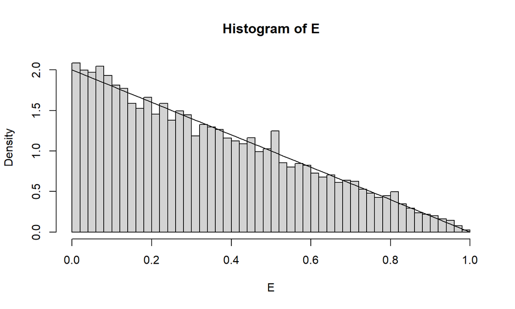

```r
E = replicate(10000, excess(151))
hist(E, prob=TRUE, breaks=50)
curve(2 - 2*x, add=TRUE)
```

## Inspection paradox

- Let us look at the size of the interval \([T_{N(t)}, T_{N(t)+1}]\) containing some \(t\);
- it turns out it is *not* uniformly distributed, and in general this interval is general has average size *larger* than \(\mathbb{E} X_1\);
- this is because larger intervals will tend to contain \(t\), so there is selection bias.

## code

```r
inspect <- function(t){
  arr  = runif(1)
  inter = arr
  while(arr[length(arr)] <t){
    inter <- c(inter, runif(1))
    arr <- c(arr, arr[length(arr)] + inter[length(inter)])
}
inter[length(inter)]
}
```

## continued

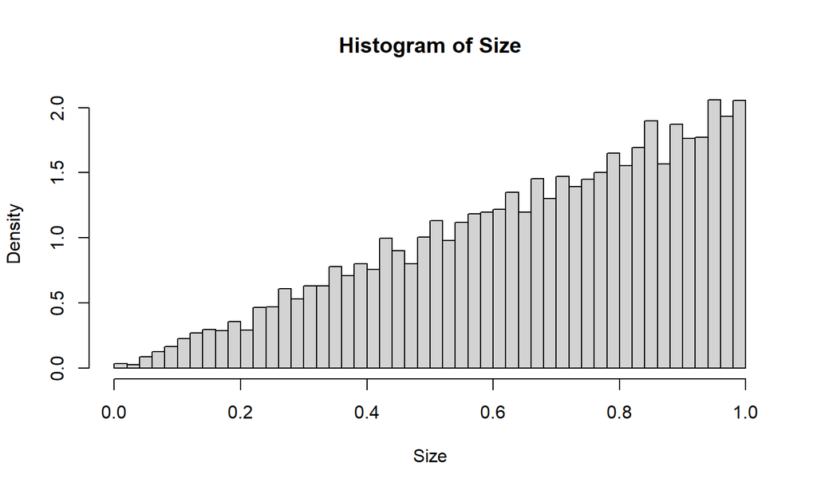

```r
Size = replicate(10000, inspect(15))
hist(Size, prob=TRUE, breaks=50)
```

## Stationary delay

The delayed renewal process has stationary increments if and only if the delay distribution has cumulative distribution given by \[F^d(y):=\frac{1}{\mu} \int_0 ^y [1-F(x)]dx,\]

where \(F\) is the cumulative distribution of original inter-arrival times, and \(\mu\) is the average.

## More renewal equations

- It is easy to verify, by condition on \(X_1\) (with law \(F^d\)) that \(m^d(t) = \mathbb{E} N^d(t)\) satisfies a renewal equation of the form \[m^d(t) = F^d(t) + \int_0 ^t m(t-x) dF^d(x).\]
- Thus \[m^d = F^d + m* F^d.\]

We already know that

\[ m = F + m* F.\]

## continued

Hence by basic properties of the star-operation, we have \[ \begin{eqnarray*} m*F^d &=& F*F^d + m * F * F^d \\ &=& F *( F^d + m*F) \\ &=& F*m^d \\ &=& m^d*F. \end{eqnarray*} \]

Hence

\[ m^d = F^d + m^d* F.\]

## Proof of Stationary delay (necessity)

- If \(N^d\) has stationary increments, then \[N^d(t+s) - N^d(t)\] has the same law as \(N^d(s)\). Hence for all \(s, t \geq 0\), we have

\[m^d(s+t)= m^d(s) +m^d(t).\]

- Since \(m^d\) satisfies Cauchy’s functional equation, it follows that \[m^d(t) = ct.\]

## continued

- In addition, we substitute \(m^d\) into one of our renewal equations to obtain that

\[ cy = F^d(y) + c\int_0 ^y F(y-x)dx= F^d(y) + c\int_0^y F(x)dx\]

- Thus

\[ F^d(y) = c\int_0 ^y [1- F(x)]dx.\]

- Taking the limit at \(y \to \infty\), we have

\[1= c \int_0 ^{\infty} [1-F(x)]dx = c\mu,\] as desired.

## Sketch proof of Blackwell’s renewal theorem

- Consider independent renewal processes \(N\) and \(N^d\), where \(N^d\) is the stationary delayed version.
- Thus \(N\) is constructed via \(X_1, X_2, \ldots\) inter-arrival times, whereas, \(N^d\) is constructed as \(X_1', X_2', \ldots, X_3, \ldots\) inter-arrival times, and the sequences \(X\) and \(X'\) are independent.
- Let \(\epsilon >0\).

## continued

- Various arguments can be used to deduce that with probability \(1\), there exists some \(i,j\) such that \[|T_i - T^d_j| < \epsilon\]
- Redefine \(N\) and \(N'\) so that, from \(i\) and \(j\) onwards, we use the same (new) i.i.d. random variables \(Z_1, Z_2, \ldots\) that have the same inter-arrival distribution as \(X_1\). Specifically, \(T_{i+1} = T_i + Z_1\) and \(T^d_{j+1} = Z_1\).
- Now the redefined \(N\) and \(N^d\) will forever be \(\epsilon\) close.

## continued

- Hence the limiting behaviour of \(N\) is the same as \(N^d\).
- The Blackwell renewal theorem is obvious for \(N^d\), since \(m^d(t)= \mu^{-1} t\).
- We remark that the analogous Blackwell renewal theorem also holds for *any* delayed renewal process.

## Some more remarks on renewal equations

Recall we started with

- \(m^d = F^d + m* F^d\) and obtained
- \(m^d = F^d + m^d * F\), the key being that
- \(m^d * F= m * F^d\).

## continued

Similar considerations give the following.

**Theorem (Uniqueness of solutions):**  
Let \(m\) be a renewal function and \(F\) be cumulative distribution function for the inter-arrival times. Let \[ \phi = H + H*m.\] Then \(\phi\) satisfies the renewal-type equation

\[ \phi = H + \phi*F;\] moreover \(\phi\) is the unique solution to the renewal-type equation, provided that \(H\) is bounded on finite intervals, which also implies that \(\phi\) is bounded on finite intervals.

## continued

If we are interested in \(\lim_{t \to \infty} \phi(t)\), we can use the form \(\phi = H + H*m\) and possibly apply the key renewal theorem:

\[\lim_{t \to \infty} \phi(t) = \lim_{t \to \infty} H(t) + \frac{1}{\mu} \int_0 ^{\infty} H(x)dx.\]

## Summary

- We stated Blackwell’s renewal theorem and the key renewal theorem.
- We discussed the connection between the limiting distribution for the excess lifetime and how this distribution can be chosen to be the delayed distribution which results in stationary increments for the associated delayed process.
- We discussed the inspection paradox and its explanation via size-biasing
- We sketched a coupling arguement for Blackwell’s renewal theorem.
- We worked with the basic mechanics of renewal equations.

## Version: 16 November 2020

- [Rmd Source](https://tsoo-math.github.io/ucl/intro-renewaltwo-slides.Rmd)